# Part I - (ProsperLoanData)

## the loan

> i this project i will analysis the loan and study the some varible and now the effect and how it role it to eachother

```python
# import all packages and set plots to be embedded inline
import numpy as np
import pandas as pd
import matplotlib.pyplot as plt
import seaborn as sb

%matplotlib inline
```

> Loan Data from Prosper: This data set contains 113,937 loans with 81 variables on each loan, ncluding loan amount, borrower rate (or interest rate), current loan status, borrower income, and many others

```python
df=pd.read_csv('prosperLoanData.csv')
df.shape
```

```
(113937, 81)
```

```python
df.head(6)
```

|  | ListingKey | ListingNumber | ListingCreationDate | CreditGrade | Term | LoanStatus | ClosedDate | BorrowerAPR | BorrowerRate | LenderYield | ... | LP_ServiceFees | LP_CollectionFees | LP_GrossPrincipalLoss | LP_NetPrincipalLoss | LP_NonPrincipalRecoverypayments | PercentFunded | Recommendations | InvestmentFromFriendsCount | InvestmentFromFriendsAmount | Investors |
| --- | --- | --- | --- | --- | --- | --- | --- | --- | --- | --- | --- | --- | --- | --- | --- | --- | --- | --- | --- | --- | --- |
| 0 | 1021339766868145413AB3B | 193129 | 2007-08-26 19:09:29.263000000 | C | 36 | Completed | 2009-08-14 00:00:00 | 0.16516 | 0.1580 | 0.1380 | ... | -133.18 | 0.0 | 0.0 | 0.0 | 0.0 | 1.0 | 0 | 0 | 0.0 | 258 |
| 1 | 10273602499503308B223C1 | 1209647 | 2014-02-27 08:28:07.900000000 | NaN | 36 | Current | NaN | 0.12016 | 0.0920 | 0.0820 | ... | 0.00 | 0.0 | 0.0 | 0.0 | 0.0 | 1.0 | 0 | 0 | 0.0 | 1 |
| 2 | 0EE9337825851032864889A | 81716 | 2007-01-05 15:00:47.090000000 | HR | 36 | Completed | 2009-12-17 00:00:00 | 0.28269 | 0.2750 | 0.2400 | ... | -24.20 | 0.0 | 0.0 | 0.0 | 0.0 | 1.0 | 0 | 0 | 0.0 | 41 |
| 3 | 0EF5356002482715299901A | 658116 | 2012-10-22 11:02:35.010000000 | NaN | 36 | Current | NaN | 0.12528 | 0.0974 | 0.0874 | ... | -108.01 | 0.0 | 0.0 | 0.0 | 0.0 | 1.0 | 0 | 0 | 0.0 | 158 |
| 4 | 0F023589499656230C5E3E2 | 909464 | 2013-09-14 18:38:39.097000000 | NaN | 36 | Current | NaN | 0.24614 | 0.2085 | 0.1985 | ... | -60.27 | 0.0 | 0.0 | 0.0 | 0.0 | 1.0 | 0 | 0 | 0.0 | 20 |
| 5 | 0F05359734824199381F61D | 1074836 | 2013-12-14 08:26:37.093000000 | NaN | 60 | Current | NaN | 0.15425 | 0.1314 | 0.1214 | ... | -25.33 | 0.0 | 0.0 | 0.0 | 0.0 | 1.0 | 0 | 0 | 0.0 | 1 |

6 rows × 81 columns

```python
df.Term.value_counts()
```

```
36    87778
60    24545
12     1614
Name: Term, dtype: int64
```

```python
df.LoanStatus.value_counts()
```

```
Current                   56576
Completed                 38074
Chargedoff                11992
Defaulted                  5018
Past Due (1-15 days)        806
Past Due (31-60 days)       363
Past Due (61-90 days)       313
Past Due (91-120 days)      304
Past Due (16-30 days)       265
FinalPaymentInProgress      205
Past Due (>120 days)         16
Cancelled                     5
Name: LoanStatus, dtype: int64
```

```python
df.dtypes
```

```
ListingKey                      object
ListingNumber                    int64
ListingCreationDate             object
CreditGrade                     object
Term                             int64
                                ...
PercentFunded                  float64
Recommendations                  int64
InvestmentFromFriendsCount       int64
InvestmentFromFriendsAmount    float64
Investors                        int64
Length: 81, dtype: object
```

```python
df.describe()
```

|  | ListingNumber | Term | BorrowerAPR | BorrowerRate | LenderYield | EstimatedEffectiveYield | EstimatedLoss | EstimatedReturn | ProsperRating (numeric) | ProsperScore | ... | LP_ServiceFees | LP_CollectionFees | LP_GrossPrincipalLoss | LP_NetPrincipalLoss | LP_NonPrincipalRecoverypayments | PercentFunded | Recommendations | InvestmentFromFriendsCount | InvestmentFromFriendsAmount | Investors |
| --- | --- | --- | --- | --- | --- | --- | --- | --- | --- | --- | --- | --- | --- | --- | --- | --- | --- | --- | --- | --- | --- |
| count | 1.139370e+05 | 113937.000000 | 113912.000000 | 113937.000000 | 113937.000000 | 84853.000000 | 84853.000000 | 84853.000000 | 84853.000000 | 84853.000000 | ... | 113937.000000 | 113937.000000 | 113937.000000 | 113937.000000 | 113937.000000 | 113937.000000 | 113937.000000 | 113937.000000 | 113937.000000 | 113937.000000 |
| mean | 6.278857e+05 | 40.830248 | 0.218828 | 0.192764 | 0.182701 | 0.168661 | 0.080306 | 0.096068 | 4.072243 | 5.950067 | ... | -54.725641 | -14.242698 | 700.446342 | 681.420499 | 25.142686 | 0.998584 | 0.048027 | 0.023460 | 16.550751 | 80.475228 |
| std | 3.280762e+05 | 10.436212 | 0.080364 | 0.074818 | 0.074516 | 0.068467 | 0.046764 | 0.030403 | 1.673227 | 2.376501 | ... | 60.675425 | 109.232758 | 2388.513831 | 2357.167068 | 275.657937 | 0.017919 | 0.332353 | 0.232412 | 294.545422 | 103.239020 |
| min | 4.000000e+00 | 12.000000 | 0.006530 | 0.000000 | -0.010000 | -0.182700 | 0.004900 | -0.182700 | 1.000000 | 1.000000 | ... | -664.870000 | -9274.750000 | -94.200000 | -954.550000 | 0.000000 | 0.700000 | 0.000000 | 0.000000 | 0.000000 | 1.000000 |
| 25% | 4.009190e+05 | 36.000000 | 0.156290 | 0.134000 | 0.124200 | 0.115670 | 0.042400 | 0.074080 | 3.000000 | 4.000000 | ... | -73.180000 | 0.000000 | 0.000000 | 0.000000 | 0.000000 | 1.000000 | 0.000000 | 0.000000 | 0.000000 | 2.000000 |
| 50% | 6.005540e+05 | 36.000000 | 0.209760 | 0.184000 | 0.173000 | 0.161500 | 0.072400 | 0.091700 | 4.000000 | 6.000000 | ... | -34.440000 | 0.000000 | 0.000000 | 0.000000 | 0.000000 | 1.000000 | 0.000000 | 0.000000 | 0.000000 | 44.000000 |
| 75% | 8.926340e+05 | 36.000000 | 0.283810 | 0.250000 | 0.240000 | 0.224300 | 0.112000 | 0.116600 | 5.000000 | 8.000000 | ... | -13.920000 | 0.000000 | 0.000000 | 0.000000 | 0.000000 | 1.000000 | 0.000000 | 0.000000 | 0.000000 | 115.000000 |
| max | 1.255725e+06 | 60.000000 | 0.512290 | 0.497500 | 0.492500 | 0.319900 | 0.366000 | 0.283700 | 7.000000 | 11.000000 | ... | 32.060000 | 0.000000 | 25000.000000 | 25000.000000 | 21117.900000 | 1.012500 | 39.000000 | 33.000000 | 25000.000000 | 1189.000000 |

8 rows × 61 columns

```python
my_col=df[['LoanOriginalAmount', 'BorrowerAPR', 'StatedMonthlyIncome', 'Term','ProsperRating (Alpha)','EmploymentStatus','LoanStatus','EmploymentStatusDuration','IncomeRange','IncomeVerifiable']]
my_col.head()
```

|  | LoanOriginalAmount | BorrowerAPR | StatedMonthlyIncome | Term | ProsperRating (Alpha) | EmploymentStatus | LoanStatus | EmploymentStatusDuration | IncomeRange | IncomeVerifiable |
| --- | --- | --- | --- | --- | --- | --- | --- | --- | --- | --- |
| 0 | 9425 | 0.16516 | 3083.333333 | 36 | NaN | Self-employed | Completed | 2.0 | $25,000-49,999 | True |
| 1 | 10000 | 0.12016 | 6125.000000 | 36 | A | Employed | Current | 44.0 | $50,000-74,999 | True |
| 2 | 3001 | 0.28269 | 2083.333333 | 36 | NaN | Not available | Completed | NaN | Not displayed | True |
| 3 | 10000 | 0.12528 | 2875.000000 | 36 | A | Employed | Current | 113.0 | $25,000-49,999 | True |
| 4 | 15000 | 0.24614 | 9583.333333 | 36 | D | Employed | Current | 44.0 | $100,000+ | True |

```python
# Remove loans with missing borrower APR information
my_col = my_col[~my_col.BorrowerAPR.isna()]
```

### What is the structure of your dataset?

> there are 113937 entries in loan data and there are 81 varibles a will not invstigate in all varible but there is an important varible such as loan term which is there three term is 12 ,36,60 and the most of the varibles here is numrical varible

### What is/are the main feature(s) of interest in your dataset?

> i'm most intersting in:
> - how will effect the BorrowerRate ?
> - what is the most term on takeing loan ?
> - Are there differences between broweer APr depinding on the user is TermProsperRating (Alpha) ?

### What features in the dataset do you think will help support your investigation into your feature(s) of interest?

- LoanOriginalAmount
- BorrowerAPR
- StatedMonthlyIncome
- TermProsperRating (Alpha)
- EmploymentStatus
- IncomeRange
- LoanStatus
- IncomeVerifiable

## Univariate Exploration

> In this section, investigate distributions of individual variables. If you see unusual points or outliers, take a deeper look to clean things up and prepare yourself to look at relationships between variables.

> **Rubric Tip**: The project (Parts I alone) should have at least 15 visualizations distributed over univariate, bivariate, and multivariate plots to explore many relationships in the data set. Use reasoning to justify the flow of the exploration.

> **Rubric Tip**: Use the "Question-Visualization-Observations" framework throughout the exploration. This framework involves **asking a question from the data, creating a visualization to find answers, and then recording observations after each visualisation.**

**in this step i will look on the genral look on the most loan state that taken**

> **Rubric Tip**: Visualizations should depict the data appropriately so that the plots are easily interpretable. You should choose an appropriate plot type, data encodings, and formatting as needed. The formatting may include setting/adding the title, labels, legend, and comments. Also, do not overplot or incorrectly plot ordinal data.

## 1 about the loan status

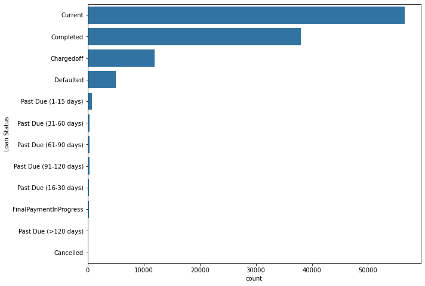

```python
plt.figure(figsize=[10, 8])
base_color=sb.color_palette()[0]
LoanStatus_order=df["LoanStatus"].value_counts().index
sb.countplot(data=df , y='LoanStatus',color=base_color,order=LoanStatus_order)
plt.ylabel('Loan Status')
plt.show()
```

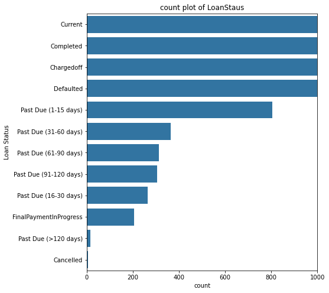

```python
plt.figure(figsize=[7,8])
loan_or=df.LoanStatus.value_counts().index
base=sb.color_palette()[0]
sb.countplot(y='LoanStatus', data=my_col,order=loan_or,color=base);
plt.xlabel("count");
plt.ylabel('Loan Status');
plt.xlim([0,1000])
plt.title('count plot of LoanStaus');
##zoom in to see what's going on clearly
```

**i made this horizontal countplot to see the distrubtion of the olan stasues and oreder it from the max to the min number so from the graph it's seems like we have for catgories is the most in the loan states which is Chargedoff, Completed, Current and the the others loan states is less than 10000**

## 2 i will pelt for next varible which is the BorrowerAPR

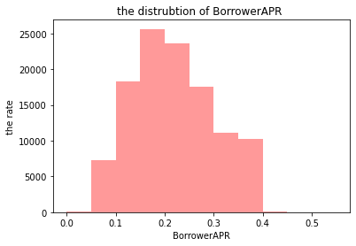

```python
b_size=0.05
bins= np.arange(0, my_col.BorrowerAPR.max()+b_size, b_size)
sb.distplot(df['BorrowerAPR'],bins=bins,kde=False,color='Red');
plt.ylabel('the rate');
plt.title('the distrubtion of BorrowerAPR ');
```

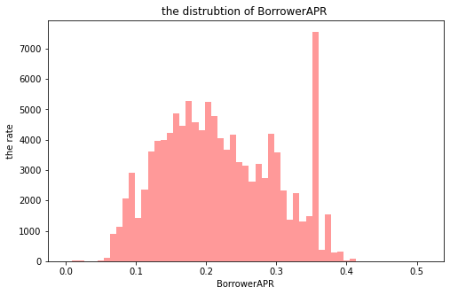

```python
plt.figure(figsize=[8,5])
b_size=0.009
bins= np.arange(0, my_col.BorrowerAPR.max()+b_size, b_size)
sb.distplot(df['BorrowerAPR'],bins=bins,kde=False,color='Red');
plt.ylabel('the rate');
plt.title('the distrubtion of BorrowerAPR ');
```

```python
my_col[my_col.BorrowerAPR>0.45]
```

|  | LoanOriginalAmount | BorrowerAPR | StatedMonthlyIncome | Term | ProsperRating (Alpha) | EmploymentStatus | LoanStatus | EmploymentStatusDuration | IncomeRange | IncomeVerifiable |
| --- | --- | --- | --- | --- | --- | --- | --- | --- | --- | --- |
| 18326 | 3000 | 0.45857 | 10000.000000 | 36 | NaN | NaN | Defaulted | NaN | Not displayed | True |
| 22195 | 1789 | 0.46201 | 2916.666667 | 36 | NaN | NaN | Chargedoff | NaN | Not displayed | True |
| 36018 | 1500 | 0.51229 | 2838.000000 | 36 | NaN | NaN | Completed | NaN | Not displayed | True |
| 56761 | 3000 | 0.50633 | 0.000000 | 36 | NaN | NaN | Defaulted | NaN | Not displayed | False |
| 82043 | 3000 | 0.48873 | 1583.333333 | 36 | NaN | NaN | Defaulted | NaN | Not displayed | True |
| 103973 | 2800 | 0.45857 | 3750.000000 | 36 | NaN | NaN | Defaulted | NaN | Not displayed | True |

**the BorrowerAPR seems it's have normal distrubation in the big bake and also in the small bake so it' a multibake distrubtion and we have some outlier between 0.3 and 0.4 also there is a few number is biger than 0.45 also the informtion in this interval is not completed**

## 3 then i will invistgte about the Term

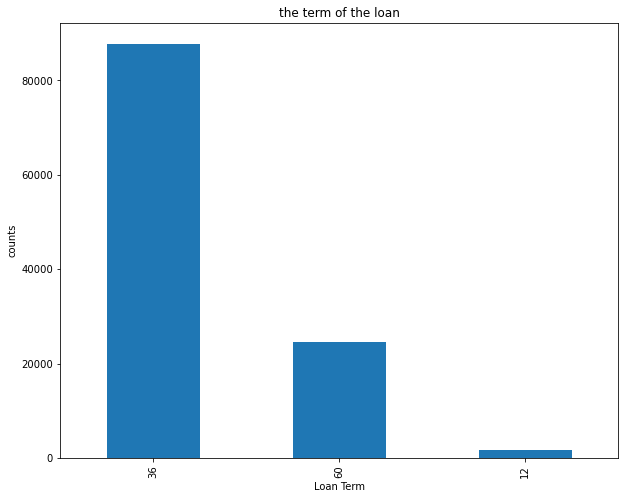

```python
most_term = my_col['Term'].value_counts()
most_term.plot(kind='bar',figsize=(10,8))
plt.title('the term of the loan');
plt.xlabel('Loan Term');
plt.ylabel('counts');
```

**from the graph we see that the long term is 36 month then 60 then the lowest is 12 month**

## 4 knowing the density of LoanOriginalAmount

```python
my_col.LoanOriginalAmount.describe()
```

```
count    113912.000000
mean       8338.015661
std        6245.940592
min        1000.000000
25%        4000.000000
50%        6500.000000
75%       12000.000000
max       35000.000000
Name: LoanOriginalAmount, dtype: float64
```

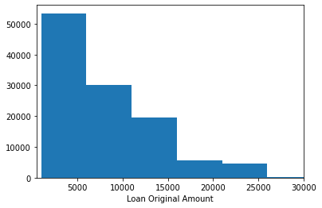

```python
## let take a look about the
bins = np.arange(1000,my_col['LoanOriginalAmount'].max()+5000, 5000)
plt.hist(data=my_col,x="LoanOriginalAmount", bins = bins)
plt.xlabel('Loan Original Amount')
plt.xlim((500,30000));
plt.show()
```

**the graph is little bit skweed so i will do a log transformtion to see the result**

```python
 np.log10(my_col.LoanOriginalAmount.describe())
#so we concloude that min number is 3 and the max number
```

```
count    5.056569
mean     3.921063
std      3.795598
min      3.000000
25%      3.602060
50%      3.812913
75%      4.079181
max      4.544068
Name: LoanOriginalAmount, dtype: float64
```

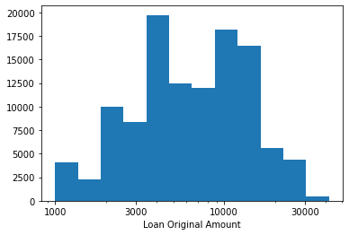

```python
# Axis transformation

# Get the ticks for bins between [0 - maximum Loan amount]
bins = 10** np.arange(3, np.log10(my_col.LoanOriginalAmount.max())+0.135, 0.135)

# Generate the x-ticks you want to apply
ticks = [1000,3000, 10000, 30000]
# Convert ticks into string values, to be displaye dlong the x-axis
labels = ['{}'.format(v) for v in ticks]
# Plot the histogram
plt.hist(data=my_col, x='LoanOriginalAmount', bins=bins);
plt.xscale('log')
plt.xlabel('Loan Original Amount')
# Apply x-ticks
plt.xticks(ticks, labels);
```

**first the graph looks like it's skweed so we well do a log transformtion to see , after the log transformation we see that the data have binmile model sence it's have tow peak the first one on 3000-4000 and the other one on 10000-20000** .

## 5 StatedMonthlyIncome

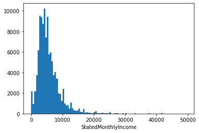

```python
bins = np.arange(0,50000,500)
plt.hist(data=my_col,x='StatedMonthlyIncome',bins=bins)
plt.xlabel('StatedMonthlyIncome')
plt.show()
```

**the StatedMonthlyIncome is have long trile skweed to right which mean the most of the income is less than 50000**

```python
#the number of StatedMonthlyIncome larger then 100000 is 17
my_col[my_col.StatedMonthlyIncome>100000]
```

|  | LoanOriginalAmount | BorrowerAPR | StatedMonthlyIncome | Term | ProsperRating (Alpha) | EmploymentStatus | LoanStatus | EmploymentStatusDuration | IncomeRange | IncomeVerifiable |
| --- | --- | --- | --- | --- | --- | --- | --- | --- | --- | --- |
| 8066 | 2000 | 0.35643 | 4.166667e+05 | 36 | HR | Employed | Completed | 183.0 | $100,000+ | True |
| 8870 | 12500 | 0.12700 | 2.083333e+05 | 36 | NaN | Not available | Chargedoff | NaN | Not displayed | True |
| 17411 | 7500 | 0.35643 | 4.833333e+05 | 36 | E | Employed | Completed | 121.0 | $100,000+ | True |
| 35218 | 1000 | 0.07389 | 1.083333e+05 | 36 | AA | Full-time | Completed | 233.0 | $100,000+ | False |
| 45028 | 4000 | 0.33973 | 1.500000e+05 | 36 | E | Self-employed | Current | 97.0 | $100,000+ | False |
| 53014 | 4000 | 0.25785 | 6.185478e+05 | 12 | D | Self-employed | Completed | 117.0 | $100,000+ | False |
| 53167 | 4000 | 0.35797 | 1.750003e+06 | 36 | HR | Self-employed | Current | 114.0 | $100,000+ | False |
| 56867 | 25000 | 0.11144 | 1.850818e+05 | 36 | NaN | Self-employed | Completed | 8.0 | $100,000+ | True |
| 57133 | 4000 | 0.35643 | 4.666667e+05 | 36 | E | Employed | Current | 271.0 | $100,000+ | True |
| 59298 | 15000 | 0.24246 | 1.208333e+05 | 36 | C | Self-employed | Current | 91.0 | $100,000+ | False |
| 63925 | 2000 | 0.25948 | 1.404167e+05 | 36 | NaN | Not available | Completed | NaN | Not displayed | True |
| 78431 | 5000 | 0.20253 | 1.033341e+05 | 36 | NaN | Full-time | Chargedoff | 10.0 | $100,000+ | True |
| 80075 | 25000 | 0.20217 | 1.583333e+05 | 36 | C | Employed | Current | 58.0 | $100,000+ | True |
| 82831 | 4000 | 0.31012 | 2.500000e+05 | 36 | E | Self-employed | Current | 137.0 | $100,000+ | False |
| 83697 | 5000 | 0.08684 | 1.850818e+05 | 36 | NaN | Not available | Completed | NaN | Not displayed | True |
| 111265 | 12765 | 0.20593 | 1.087500e+05 | 60 | B | Employed | Completed | 84.0 | $100,000+ | True |
| 113270 | 2000 | 0.22712 | 3.944000e+05 | 36 | C | Employed | Current | 173.0 | $100,000+ | True |

```python
#the percent of the browwer is
(my_col.StatedMonthlyIncome>=30000).sum()/113912*100
```

```
0.307254722944027
```

```python
my_col = my_col[my_col.StatedMonthlyIncome<30000]
#cheak from deleating
(my_col.StatedMonthlyIncome>=30000).sum()
```

```
0
```

## 6 EmploymentStatus

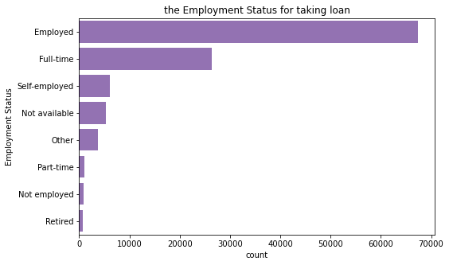

```python
plt.figure(figsize=[8,5])
E_order=my_col.EmploymentStatus.value_counts().index
base_color=sb.color_palette()[4]
sb.countplot(data = df, y = 'EmploymentStatus',color=base_color, order=E_order)
plt.ylabel('Employment Status')
plt.title('the Employment Status for taking loan')
plt.show()
```

**we have the most of job stauts that takeing loan is either is Employed or full-time and the other states is less than 10000**

## 7 IncomeRange

```python
#to order the interval correctly
my_col.IncomeRange.value_counts()
```

```
$25,000-49,999    32192
$50,000-74,999    31049
$100,000+         17015
$75,000-99,999    16915
Not displayed      7690
$1-24,999          7274
Not employed        806
$0                  621
Name: IncomeRange, dtype: int64
```

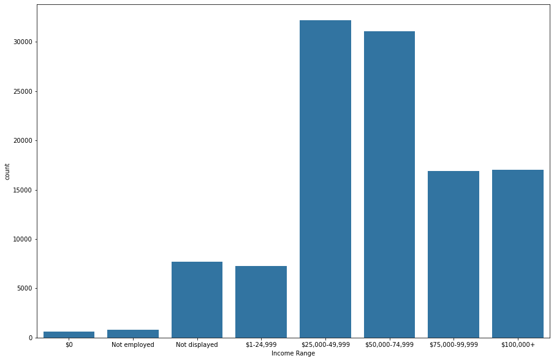

```python
plt.figure(figsize=[15, 10])
base_color=sb.color_palette()[0]
Income_order=["$0", "Not employed","Not displayed","$1-24,999","$25,000-49,999","$50,000-74,999","$75,000-99,999","$100,000+" ]
sb.countplot(data = my_col, x= 'IncomeRange',color=base_color,order=Income_order)
plt.xlabel('Income Range')
plt.show()
```

**the 30K or more from brower taker they take income range from $25,000-74,999 and more than 15K they take from 75,000 and more than $100,000+ income range and less than 10k either they don't displayed or take income range from $1-24,999 and less than 5k they Not employed or take 0**

## 8 ProsperRating

```python
order=['HR','E','D','C','B','A','AA']
rate_order =pd.api.types.CategoricalDtype(ordered=True,categories=order)
my_col['ProsperRating (Alpha)'] = my_col['ProsperRating (Alpha)'].astype(rate_order)
```

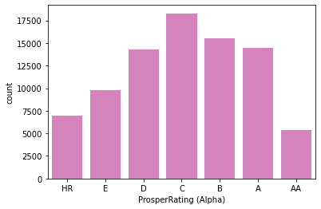

```python
default_color = sb.color_palette()[6]
sb.countplot(data = my_col, x = 'ProsperRating (Alpha)',order=order, color = default_color);
```

```python
my_col['ProsperRating (Alpha)'].value_counts()
```

```
C     18288
B     15512
A     14488
D     14251
E      9785
HR     6918
AA     5345
Name: ProsperRating (Alpha), dtype: int64
```

**the most prosper Rating is from C to A and this have almost normal distrubtion**

## 9 catgirocal varible

```python
plt.figure(figsize=[8,5])
default_color = sb.color_palette()[4]
sb.countplot(data = my_col, x = 'IncomeVerifiable', color = default_color);
```

[output not shown]

## Bivariate Exploration

> In this section, investigate relationships between pairs of variables in your data. Make sure the variables that you cover here have been introduced in some fashion in the previous section (univariate exploration).

### Did you observe any interesting relationships between the other features (not the main feature(s) of interest)?

```python
# you can add recomondation it's good
num_vars = ['LoanOriginalAmount', 'BorrowerAPR', 'StatedMonthlyIncome']
cat_vars = ['Term', 'ProsperRating (Alpha)', 'EmploymentStatus','IncomeRange','LoanStatus','IncomeVerifiable']
```

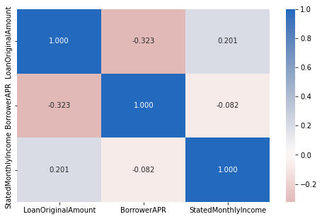

```python
plt.figure(figsize = [8, 5])
sb.heatmap(df[num_vars].corr(), annot = True, fmt = '.3f',
           cmap = 'vlag_r', center = 0)
plt.show()
```

so from the heat map it seem there corrleation between varible but not that strong

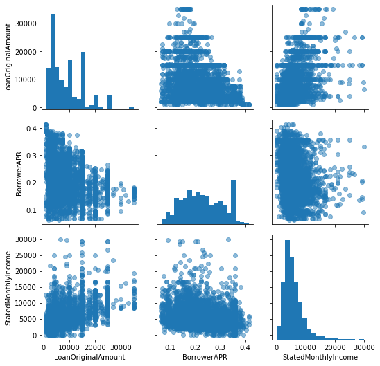

```python
# plot matrix: sample 5000 loans so that plots are clearer and render faster
my_samp = my_col.sample(5000)
g = sb.PairGrid(data = my_samp.dropna(), vars = num_vars)
g = g.map_diag(plt.hist, bins=20)
g.map_offdiag(plt.scatter, alpha=0.5);
```

from the grph and this plot we conclude there is a negtive realtionship between BorrowerAPR and LoanOriginalAmount so if LoanOriginalAmount increase the BorrowerAPR will decrase but it's not a strong realtionship

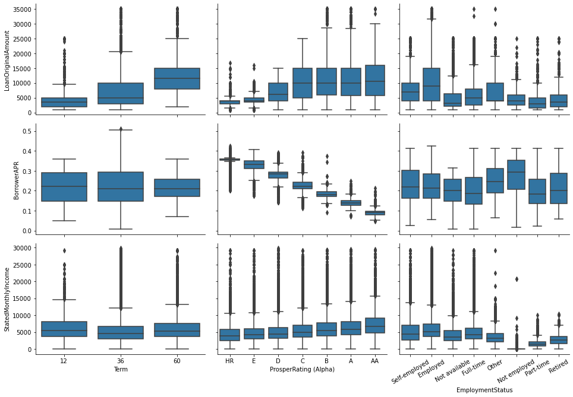

```python
def boxgrid(x, y, **kwargs):
    default_color = sb.color_palette()[0]
    sb.boxplot(x, y, color = default_color)

plt.figure(figsize = [10,10])
g = sb.PairGrid(data = my_col, y_vars = num_vars,  x_vars = ['Term', 'ProsperRating (Alpha)','EmploymentStatus'], size = 3, aspect = 1.5);
g.map(boxgrid);
plt.xticks(rotation=30);
```

```python
plt.figure(figsize = [20, 30])
Rotation=60
ncolno=5
# subplot 1: Prosper rating vs term
ax1= plt.subplot(5, 1, 1)
sb.countplot(data = my_col, x = 'ProsperRating (Alpha)', hue = 'Term', palette = 'Blues')
ax1.legend(loc = 1, ncol = ncolno) ;
plt.xticks(rotation=Rotation);
# subplot 2: employment status vs. term
ax = plt.subplot(5, 1, 2)
sb.countplot(data = my_col, x = 'EmploymentStatus', hue = 'IncomeVerifiable', palette = 'Reds')
plt.xticks(rotation=10)
ax1.legend(loc = 1, ncol = ncolno) ;

# subplot 3: Prosper rating vs. employment status, use different color palette
ax = plt.subplot(5, 1, 3)
sb.countplot(data = my_col, x = 'EmploymentStatus', hue = 'ProsperRating (Alpha)', palette = 'Greens')
ax.legend(loc = 1, ncol = 2); # re-arrange legend to remove overlapping
plt.xticks(rotation=10);
ax1.legend(loc = 1, ncol = ncolno) ;
```

[output not shown]

## Multivariate Exploration

> Create plots of three or more variables to investigate your data even further. Make sure that your investigations are justified, and follow from your work in the previous sections.

```python
cat_vars
```

```
['Term',
 'ProsperRating (Alpha)',
 'EmploymentStatus',
 'IncomeRange',
 'LoanStatus',
 'IncomeVerifiable']
```

```python
my_col
```

|  | LoanOriginalAmount | BorrowerAPR | StatedMonthlyIncome | Term | ProsperRating (Alpha) | EmploymentStatus | LoanStatus | EmploymentStatusDuration | IncomeRange | IncomeVerifiable |
| --- | --- | --- | --- | --- | --- | --- | --- | --- | --- | --- |
| 0 | 9425 | 0.16516 | 3083.333333 | 36 | NaN | Self-employed | Completed | 2.0 | $25,000-49,999 | True |
| 1 | 10000 | 0.12016 | 6125.000000 | 36 | A | Employed | Current | 44.0 | $50,000-74,999 | True |
| 2 | 3001 | 0.28269 | 2083.333333 | 36 | NaN | Not available | Completed | NaN | Not displayed | True |
| 3 | 10000 | 0.12528 | 2875.000000 | 36 | A | Employed | Current | 113.0 | $25,000-49,999 | True |
| 4 | 15000 | 0.24614 | 9583.333333 | 36 | D | Employed | Current | 44.0 | $100,000+ | True |
| ... | ... | ... | ... | ... | ... | ... | ... | ... | ... | ... |
| 113932 | 10000 | 0.22354 | 4333.333333 | 36 | C | Employed | Current | 246.0 | $50,000-74,999 | True |
| 113933 | 2000 | 0.13220 | 8041.666667 | 36 | A | Employed | FinalPaymentInProgress | 21.0 | $75,000-99,999 | True |
| 113934 | 10000 | 0.23984 | 2875.000000 | 60 | D | Employed | Current | 84.0 | $25,000-49,999 | True |
| 113935 | 15000 | 0.28408 | 3875.000000 | 60 | C | Full-time | Completed | 94.0 | $25,000-49,999 | True |
| 113936 | 2000 | 0.13189 | 4583.333333 | 36 | A | Employed | Current | 244.0 | $50,000-74,999 | True |

113562 rows × 10 columns

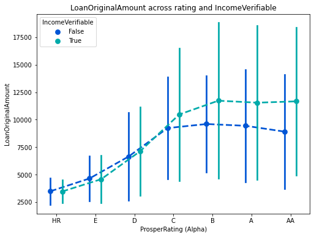

```python
fig = plt.figure(figsize = [8,6])
ax = sb.pointplot(data = my_col, x = 'ProsperRating (Alpha)', y = 'LoanOriginalAmount', hue = 'IncomeVerifiable',
           palette = 'winter', linestyles = '--', dodge = 0.3, ci='sd')
plt.title('LoanOriginalAmount across rating and IncomeVerifiable')
plt.ylabel('LoanOriginalAmount')
ax.set_yticklabels([],minor = True);
```

**Both Rating and incom verving is incresing with the highest number ofriginal Amount

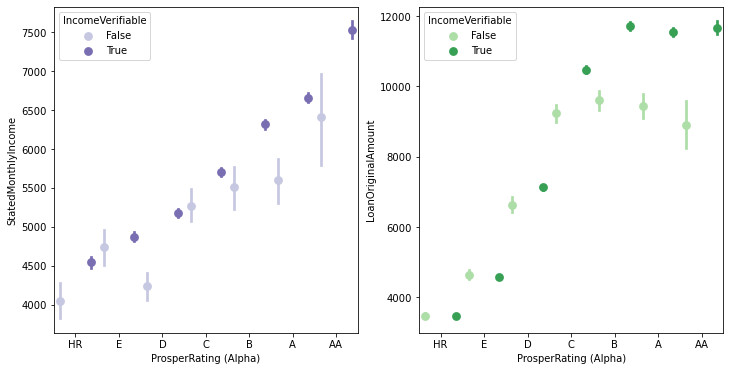

```python
fig, ax = plt.subplots(ncols=2, figsize=[12,6])
sb.pointplot(data = my_col, x = 'ProsperRating (Alpha)', y = 'StatedMonthlyIncome', hue = 'IncomeVerifiable',
           palette = 'Purples', linestyles = 'none', dodge = 0.7, ax=ax[0])
sb.pointplot(data = my_col, x = 'ProsperRating (Alpha)', y = 'LoanOriginalAmount', hue = 'IncomeVerifiable',
           palette = 'Greens', linestyles = 'none', dodge = 0.7, ax=ax[1]);
```

there is relationship that the most of the income vevible haveing high state monthly income and also loan orginal amout also there alot of them in the higher rating

### Talk about some of the relationships you observed in this part of the investigation. Were there features that strengthened each other in terms of looking at your feature(s) of interest?

> i find an intresting realtion between the rating and the loan orignal amount so we the amount increase also the rating is increase also i find that the most of the rating comes from the employed

### Were there any interesting or surprising interactions between features?

> the ProsperRating (Alpha) is incresing with the satae monthly income so it's gave me that is reltead to each other the LoanOriginalAmount is increasing with the term increasing

## Conclusions

> i don't add all the lables beacues i think the title is gave the informtion about the graph there is a lot of making sence in this data and when i make the grph make relsitc even more this the last project and i hope it completate

> Remove all Tips mentioned above, before you convert this notebook to PDF/HTML

> At the end of your report, make sure that you export the notebook as an html file from the `File > Download as... > HTML or PDF` menu. Make sure you keep track of where the exported file goes, so you can put it in the same folder as this notebook for project submission. Also, make sure you remove all of the quote-formatted guide notes like this one before you finish your report!

## Helpful resorses

https://seaborn.pydata.org/generated/seaborn.PairGrid.html

https://towardsdatascience.com/how-to-do-a-custom-sort-on-pandas-dataframe-ac18e7ea5320